# About

*Update of the website in progress*

**Important news!**  
We are organizing the “*The 2025 conference on the Mosaic of East Asian Language Processing: Exploring Taiwan’s diversity and beyond*”. More information on the website of the conference [here](https://sites.google.com/view/mealp-2025/home)!

**2024/06/25**  
The manuscript entitled “A decade of language processing research: Which place for linguistic diversity?” is now available online in *Glossa Psycholinguistics* [here](https://doi.org/10.5070/G60111432)!

**2024/05/09**  
The manuscript entitled “It costs to exist: Acceptability judgments of the temporal concord of the auxiliary verbs *you* and *hui* in Taiwan Mandarin” is now available online in *Journal of Psycholinguistic Research* [here](https://doi.org/10.1007/s10936-024-10086-5)!

**Upcoming presentation(s)**

- **2025/04/17-19**: “*‘Computer or smartphone, as you please’: On the device effect in web-based acceptability judgment experiments*”, poster presentation at the 5th International Conference on Theoretical East Asian Psycholinguistics (ICTEAP-5), Tokyo, Japan
- **2025/05/07-09**: “*In the clouds and on the ground: Taiwan as a laboratory to expand the typological pool of psycholinguistic research*”, oral presentation at the Linguistic data and language comparison in light of the ‘quantitative turn’ and ‘big data’ - a workshop and symposium, Bern, Switzerland
- **2025/05/21-23**: “*A tale of the lab and the field: An opportunity for Formosan language research*”, oral presentation at the 5th World Congress of Taiwan Studies (Taiwan in a changing world: Past, present, and future), Taipei, Taiwan

### Short bio

I am an assistant professor at the Department of Chinese of National Taiwan Normal University, focusing on corpus and experimental explorations of language in general and grammar in particular.  
Previously, I was a postdoctoral researcher at the Institute of Linguistics of Academia Sinica, Taiwan. I worked on two individual projects: (1) “On the expression of temporal reference with modal information from a morphosyntactic and psycho-/neuro-linguistic perspective: The case of ‘*you* (to have) + VP’ in Taiwan Mandarin” (2022-2024), and (2) “Paving the way for ‘field psycholinguistics’ of Formosan languages: Case studies in Truku Seediq, Bunun and Tsou” (2024-2025), with a grant from the Academia Sinica postdoctoral scholar program.  
Before that, I graduated from the PhD program of the department of English of National Taiwan Normal University (Linguistic track) in June 2022. During my PhD studies, I was also the manager of the [Neurolinguistics Lab](https://sites.google.com/view/neurolinguisticslabntnu) of National Taiwan Normal University, where I supervized behavioral, ERP and fMRI experiments about a great variety of language-related topics, such as language relativity, classifier processing or conceptual categorization.

### Research interests

My main research interests combine two disciplines: linguistics and cognitive science (including language processing). My main area of research can be summarized as follows:

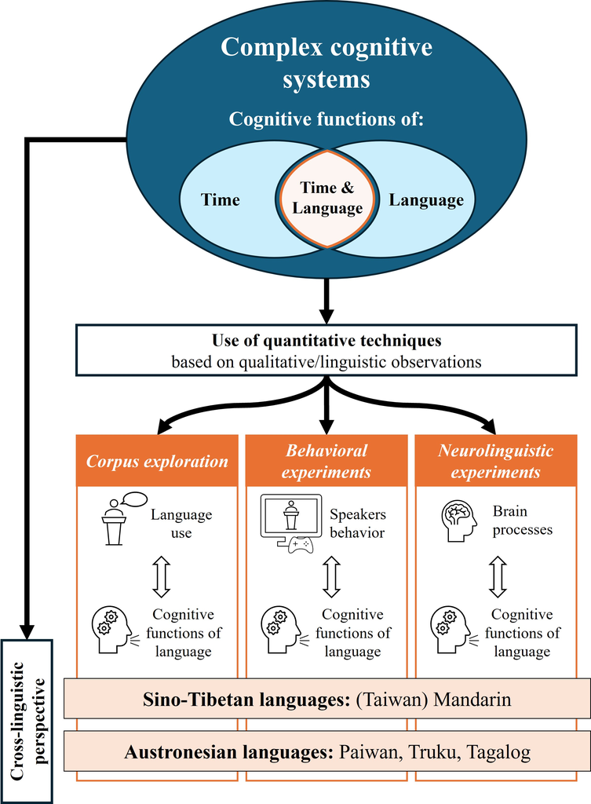

* On the linguistic side, I am interested in the syntax and semantics of the expression of time reference from a functional syntax and user-based perspective. Particularly, I aim at understanding how temporal relations are expressed with grammatical markers in tenseless languages, with a focus on Mandarin Chinese (and its variety spoken in Taiwan). * On the cognitive science side, I have mainly worked in sentence processing using psycholinguistic and neurolinguistic techniques with a focus on the processing of temporality (tense, aspect, mood and modality) in grammar.

I aim at bridging linguistic analyses with their brain processing patterns in order to establish a neurolinguistic and crosslinguistic model of the processing of temporality at the sentence level. Although I have mainly focused on Mandarin Chinese so far, I wish to expand my research to other languages, especially languages which are underrepresented in the language processing domain.

My research interests lie in the following topics (click on the image for more details):

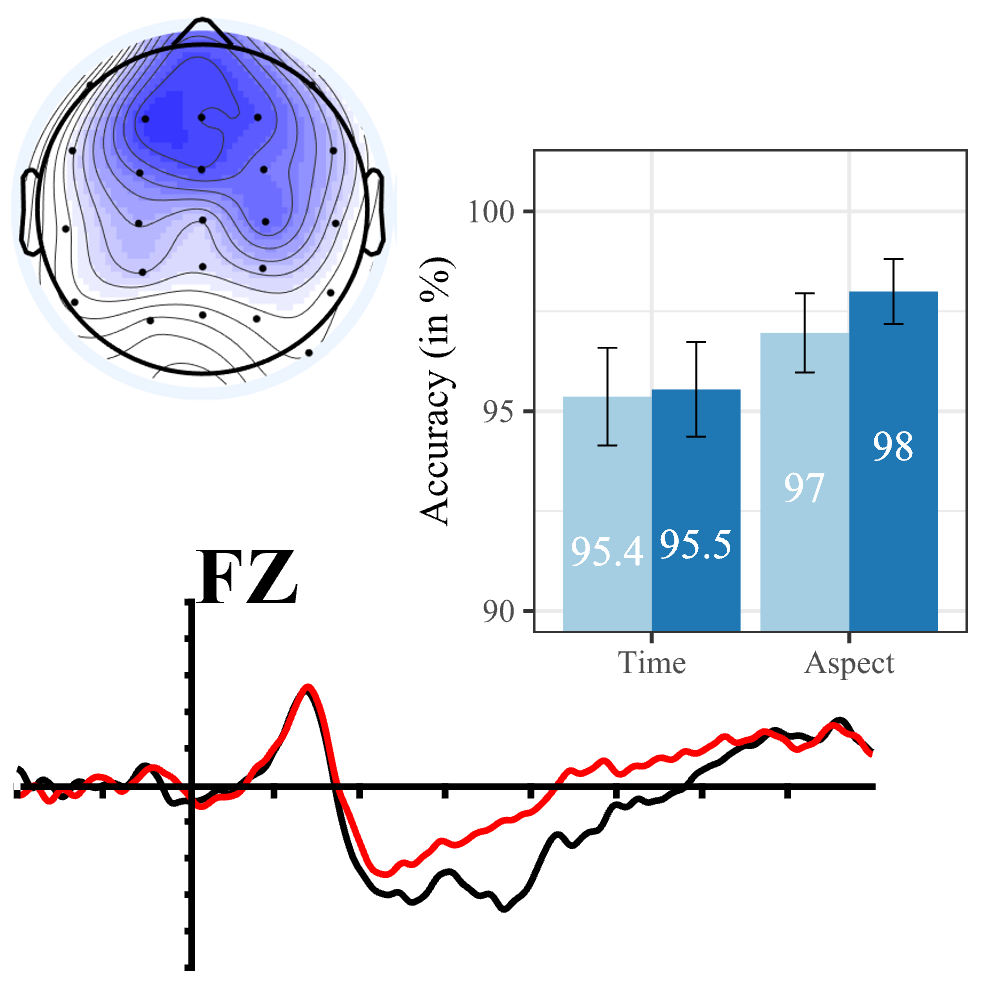

**Temporal reference in (Taiwan) Mandarin: Syntax and semantics, Corpus and experiments**

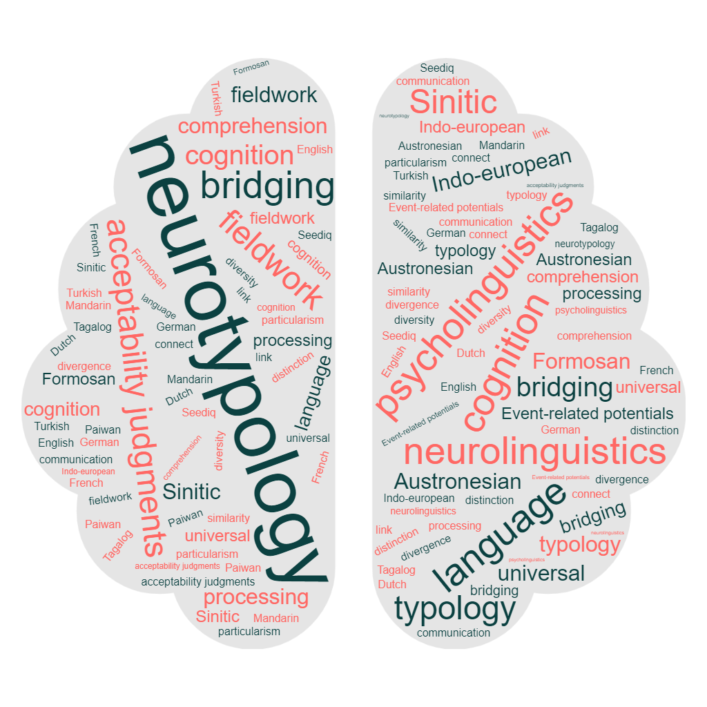

**Crosslinguistic language processing: Linguistic and cognitive diversities of the mind**

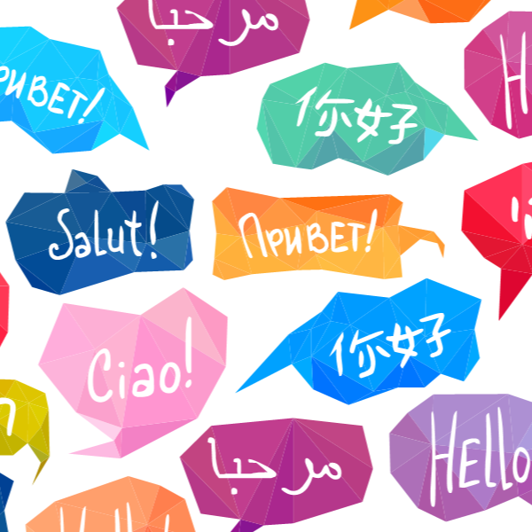

**Applied language processing: Interpreting, and language learning and teaching**

Last update: 2025/08/09